# FIN_654_WK3_R

Kendra Osburn

7/22/2019

# UNIT 3 | MACROFINANCIAL ANALYSIS

## 3.1. Readings

## 3.2 Exercise: Imagine This

## 3.3 Exercise: Stylized Facts

```r
library(fBasics)
#extreme value (used by hurricane people)
library(evir)
library(qrmdata)
library(zoo)
data(OIL_Brent)
str(OIL_Brent)
```

```
## An 'xts' object on 1987-05-20/2015-12-28 containing:
##   Data: num [1:7258, 1] 18.6 18.4 18.6 18.6 18.6 ...
##  - attr(*, "dimnames")=List of 2
##   ..$ : NULL
##   ..$ : chr "OIL_Brent"
##   Indexed by objects of class: [Date] TZ: UTC
##   xts Attributes:
##  NULL
```

Look specifically at price

```r
Brent.price <- as.zoo(OIL_Brent)
str(Brent.price)
```

```
## 'zoo' series from 1987-05-20 to 2015-12-28
##   Data: num [1:7258, 1] 18.6 18.4 18.6 18.6 18.6 ...
##  - attr(*, "dimnames")=List of 2
##   ..$ : NULL
##   ..$ : chr "OIL_Brent"
##   Index:  Date[1:7258], format: "1987-05-20" "1987-05-21" "1987-05-22" "1987-05-25" "1987-05-26" ...
```

```r
# Removing the first row with [-1] because we can't get a return on first value
Brent.return <- diff(log(Brent.price))[-1]*100
colnames(Brent.return) <- "Brent.return"
head(Brent.return, n=5)
```

```
##            Brent.return
## 1987-05-22    0.5405419
## 1987-05-25    0.2691792
## 1987-05-26    0.1611604
## 1987-05-27   -0.1611604
## 1987-05-28    0.0000000
```

```r
tail(Brent.return, n=5)
```

```
##            Brent.return
## 2015-12-21   -3.9394831
## 2015-12-22   -0.2266290
## 2015-12-23    1.4919348
## 2015-12-24    3.9177726
## 2015-12-28   -0.3768511
```

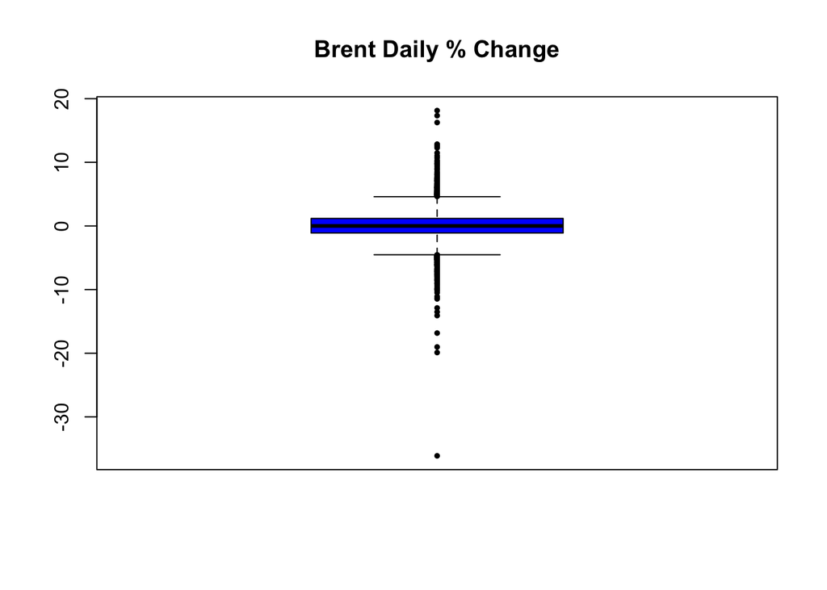

```r
boxplot(as.vector(Brent.return), title = FALSE,
        main = "Brent Daily % Change", col = "blue", cex = 0.5, pch = 19)
```

```r
skewness(Brent.return)
```

```
## [1] -0.6210447
## attr(,"method")
## [1] "moment"
```

```r
kurtosis(Brent.return)
```

```
## [1] 14.62226
## attr(,"method")
## [1] "excess"
```

##### Skewness

*Skewness describes the lean of the distribution. A positive skew means you have a left lean and a long right tail (a chi-square distribution is positively skewed). This means that the mean (center of gravity) is to the right of the bulk of your data.* [https://www.reddit.com/r/explainlikeimfive/comments/610nc0/eli5_what_are_moments_skewness_and_kurtosis_in/]

##### Kurtosis

*Kurtosis describes how fat the distribution’s tails are. It tells you how likely it is to find extreme values in your data. Higher values make outliers more likely ( the tails are fatter). This sounds a lot like spread (variance) but is subtly different.* [https://www.reddit.com/r/explainlikeimfive/comments/610nc0/eli5_what_are_moments_skewness_and_kurtosis_in/]

[figure not shown]

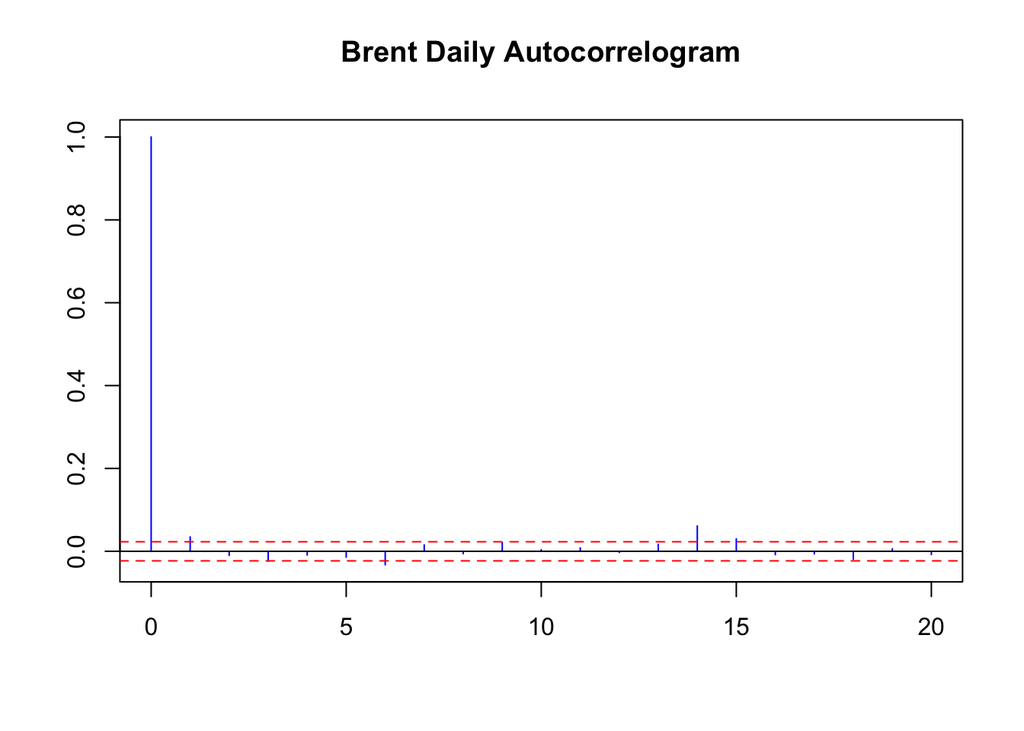

```r
acf(coredata(Brent.return), main = "Brent Daily Autocorrelogram",
    lag.max=20, ylab = "", xlab = "",
    col = "blue", ci.col = "red")
```

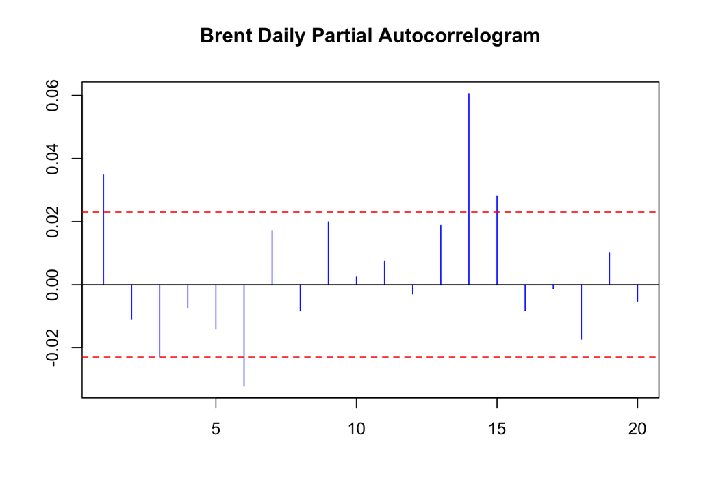

```r
pacf(coredata(Brent.return), main = "Brent Daily Partial Autocorrelogram",
    lag.max=20, ylab = "", xlab = "",
    col = "blue", ci.col = "red")
```